# Assignment 2, Titanic Analysis

Robby Jeffries

9/25/2021

### What actually happened on that fateful day?

On April 15th, 1912, the “unsinkable” happened. The RMS Titanic sank. Although detailed information exists for many of the passengers, many people have never explored the data surrounding this voyage. Let’s take a closer look at this data and uncover the details of this historic event.

I referenced [this page](https://medium.com/analytics-vidhya/a-beginners-guide-to-learning-r-with-the-titanic-dataset-a630bc5495a8) as I considered my analysis.

### Question 1: Who lived and who died, demographically?

Let’s first take a look at how many people lived and how many people died. The data set we are analyzing contains information for 1309 passengers. Of those 1309, the data set contains survival information for 891 passengers.

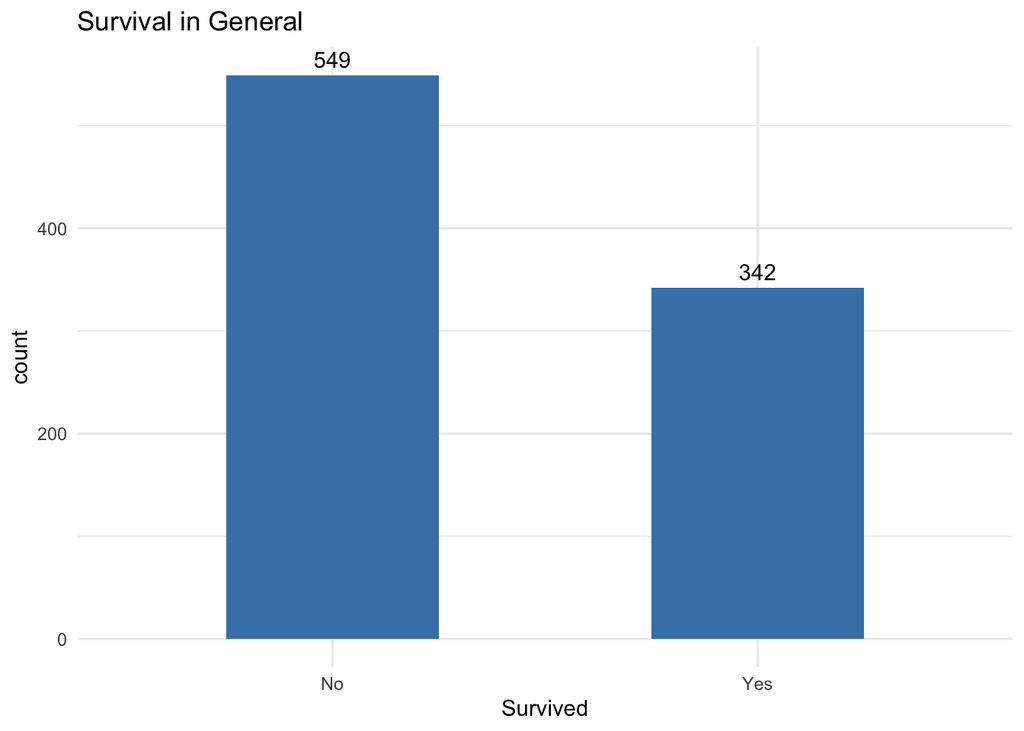

### Question 2: Was gender a factor?

From the previous graph, we can see that **549** people died and **342** people survived. Let’s double-click on this stat and analyze the survival rate by sex.

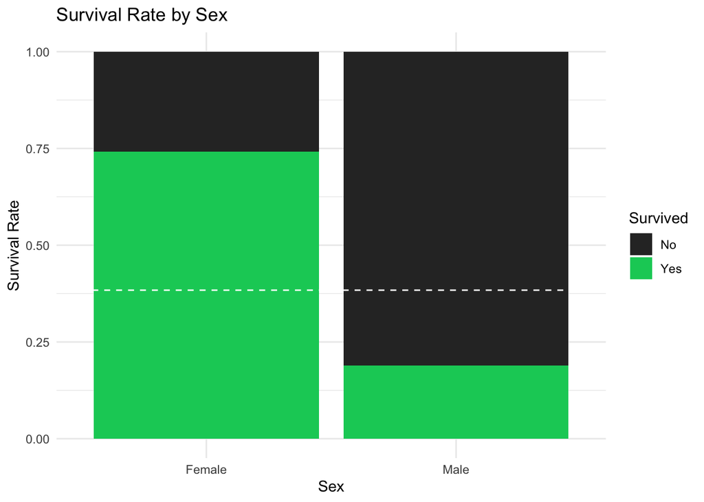

As the above chart shows, the majority of women survived, and the majority of men died. The white horizontal line represents the average survival rate without regard to sex. This shows us that the men’s survival rate was below-average, and the women’s survival rate was above-average. This is consistent with our expectation because women and children were given priority on the lifeboats.

### Question 3: Was class of service a factor?

The passengers were in three different classes: 1st, 2nd, and 3rd. How many people died in each class?

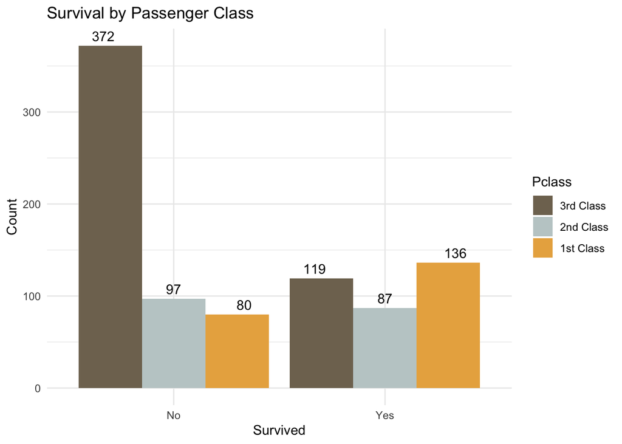

### Question 4: What other patterns do you see in the data?

#### What did the survival rate look like by age?

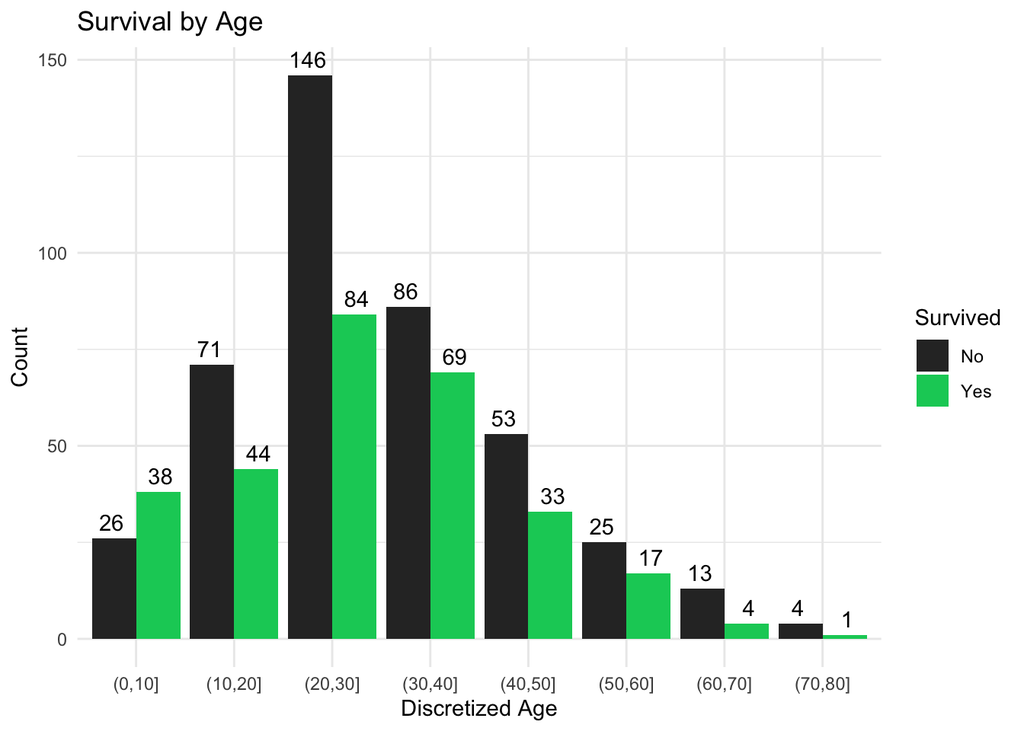

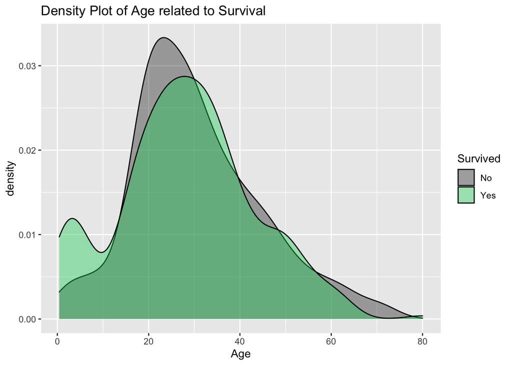

### Question 5: What is something surprising in the data that others may have missed?

#### What did the survival rate look like by fare price?

When people think about the victims of the Titanic’s sinking, they may intuitively associate age or status with survival. Let’s add a level of granularity. Since this data set contains the price of each passenger’s fare, let’s check whether or not the amount of money that someone spent on their ticket impacted their survival.

Perhaps those that spent more money on their ticket were more cognizant of how to navigate the ship and claim a spot on a lifeboat? Let’s take a look.

*Note: Although some passengers received a free ticket, most passengers spent money on their fare.*

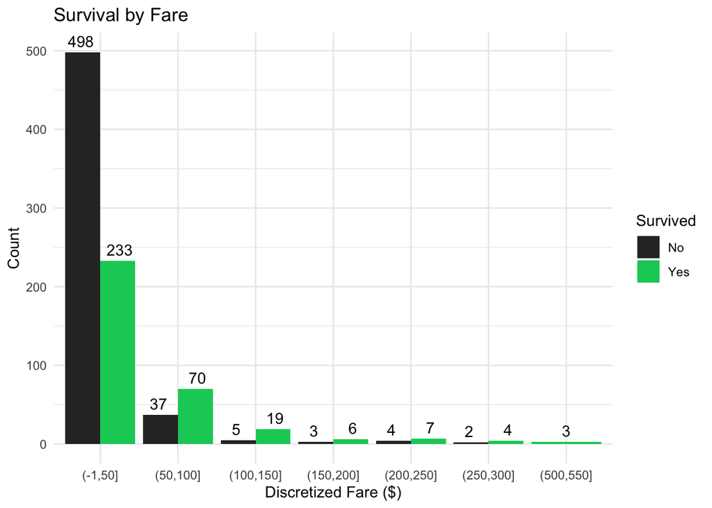

Interestingly, approximately two-thirds of the passengers who spent the least amount of money died in the chaos. As the fare price increased, we see that the majority of passengers survived. Further, all three passengers that spent between $500-$550 survived. The plot above contains a strong right-skew. To account for this, let’s create a density plot on a log scale.

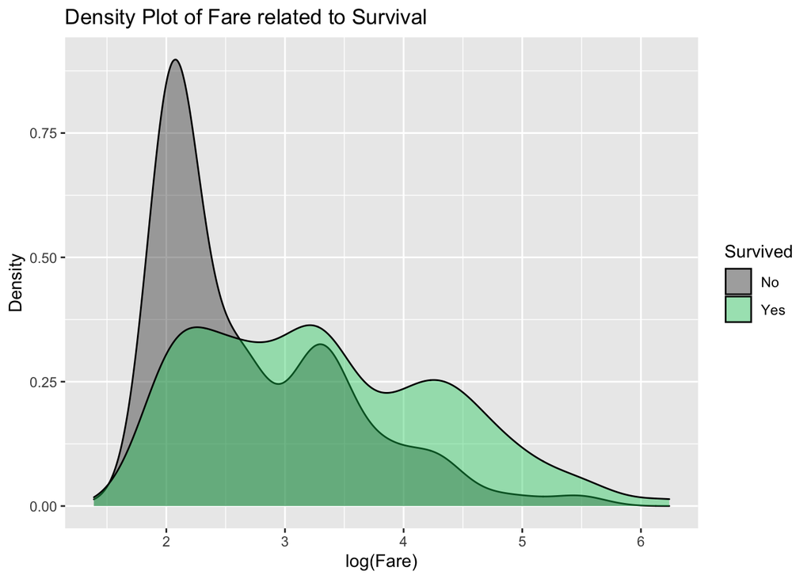

Sure enough, the log scale shows us that the passengers with cheaper tickets had a significantly greater risk of dying. Further analysis would be required before causal inferences could be made, but a correlation between survival and fare certainly exists.

### Logistic Regression to predict survival

*Caveat: I did not know how to approach regression analysis off-hand; so I went to Google. I discovered [this page](https://rpubs.com/abhaypadda/logistic-regression-using-titanic-data), written by Abhay Padda. For practice, I replicated his code here. While much of Padda’s code worked as written, several sections requried modifications to work with our data set.*

Logistic regressions are useful when the dependent variable is binary. In this case, our dependent variable is survival (0 = died, 1 = survived). When logistic functions are plotted, they resemble an elongated letter ‘s’. For a given value along the x-axis, the plot will tell you the probability that the passenger survived.

A question arises: at what threshold should a probability be classified as a survival or a death? 50%? 65%? That is where the [**Receiver Operating Characteristic (ROC) curve**](https://en.wikipedia.org/wiki/Receiver_operating_characteristic) comes into play. The ROC curve is built by (1) running a logistic regression and (2) computing a [confusion matrix](https://en.wikipedia.org/wiki/Confusion_matrix) for each individual passenger, which defines a new threshold of survival for each passenger.

The end goal is to strike an optimal balance between the true positive rate and the false positive rate. The following graph show the ROC curve for the Titanic data set, and the optimal configuration is near the top left corner. As we might have intuitively guessed for a simple data set such as this, a good probability threshold for predicting survival is approximately 50%.

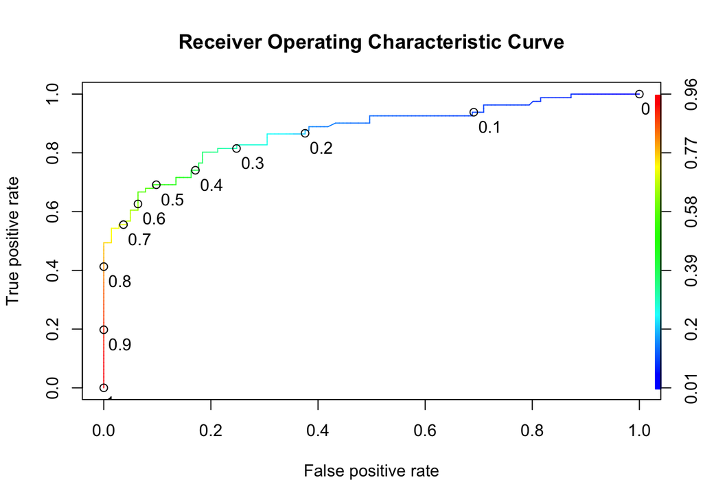

The area under the curve (AUC) is 0.87. This value is meaningful if you want to compare multiple ROC curves and determine which one is the best model. The greater the AUC, the better the model. An area of 1.00 or 100% is a perfect test. Therefore, I conclude that the AUC of the above graph is ‘pretty good’ with an area of 87.

For additional information regarding ROC and AUC, I watched this [StatQuest with Josh Starmer](https://www.youtube.com/watch?v=4jRBRDbJemM).